## Missing data

```r
data = read.csv("subset_with_missing.csv")
data$X = NULL  # Remove index variable
summary(data)
```

```
##   income_1988       grade_1996    unemployment_1991   grade_1992
##  Min.   :     0   Min.   : 0.00   Min.   : 0.000    Min.   : 0.00
##  1st Qu.: 12200   1st Qu.:12.00   1st Qu.: 0.000    1st Qu.:12.00
##  Median : 22800   Median :12.00   Median : 0.000    Median :12.00
##  Mean   : 26701   Mean   :13.08   Mean   : 2.359    Mean   :12.96
##  3rd Qu.: 36000   3rd Qu.:14.00   3rd Qu.: 0.000    3rd Qu.:14.00
##  Max.   :100001   Max.   :20.00   Max.   :52.000    Max.   :20.00
##  NA's   :853      NA's   :161     NA's   :217       NA's   :121
##    grade_1984    income_1980    unemployment_2006  income_1993
##  Min.   : 0.0   Min.   :    0   Min.   : 0.000    Min.   :     0
##  1st Qu.:12.0   1st Qu.: 7500   1st Qu.: 0.000    1st Qu.: 17800
##  Median :12.0   Median :15000   Median : 0.000    Median : 32600
##  Mean   :12.4   Mean   :18362   Mean   : 1.818    Mean   : 38744
##  3rd Qu.:13.0   3rd Qu.:25000   3rd Qu.: 0.000    3rd Qu.: 51000
##  Max.   :20.0   Max.   :75001   Max.   :52.000    Max.   :160097
##  NA's   :86     NA's   :801     NA's   :379       NA's   :877
##  unemployment_1979  income_2006       grade_1983   unemployment_1987
##  Min.   : 0.000    Min.   :     0   Min.   : 0.0   Min.   : 0.000
##  1st Qu.: 0.000    1st Qu.: 25948   1st Qu.:12.0   1st Qu.: 0.000
##  Median : 0.000    Median : 53906   Median :12.0   Median : 0.000
##  Mean   : 4.644    Mean   : 69658   Mean   :12.2   Mean   : 3.615
##  3rd Qu.: 4.000    3rd Qu.: 89930   3rd Qu.:13.0   3rd Qu.: 1.000
##  Max.   :52.000    Max.   :479983   Max.   :19.0   Max.   :52.000
##  NA's   :1505      NA's   :431      NA's   :78     NA's   :218
##   income_1983     income_2000      income_2004       grade_1998
##  Min.   :    0   Min.   :     0   Min.   :     0   Min.   : 0.00
##  1st Qu.: 8500   1st Qu.: 22114   1st Qu.: 25840   1st Qu.:12.00
##  Median :16000   Median : 44000   Median : 51800   Median :12.00
##  Mean   :20215   Mean   : 55257   Mean   : 65464   Mean   :13.12
##  3rd Qu.:28000   3rd Qu.: 70098   3rd Qu.: 84530   3rd Qu.:14.00
##  Max.   :75001   Max.   :332808   Max.   :408473   Max.   :20.00
##  NA's   :816     NA's   :920      NA's   :777      NA's   :218
##   income_1987       grade_1994    unemployment_1985   grade_1993
##  Min.   :     0   Min.   : 0.00   Min.   : 0.000    Min.   : 0
##  1st Qu.: 11500   1st Qu.:12.00   1st Qu.: 0.000    1st Qu.:12
##  Median : 21103   Median :12.00   Median : 0.000    Median :12
##  Mean   : 25654   Mean   :13.03   Mean   : 4.347    Mean   :13
##  3rd Qu.: 34770   3rd Qu.:14.00   3rd Qu.: 3.000    3rd Qu.:14
##  Max.   :100001   Max.   :20.00   Max.   :52.000    Max.   :20
##  NA's   :819      NA's   :114     NA's   :139       NA's   :103
```

[output cut: 81 more lines]

```
##  Min.   :    0   Min.   : 0.000    Min.   : 0.000    Min.   :     0
##  1st Qu.: 7640   1st Qu.: 0.000    1st Qu.: 0.000    1st Qu.: 10274
##  Median :15154   Median : 0.000    Median : 0.000    Median : 19941
##  Mean   :18920   Mean   : 1.451    Mean   : 1.935    Mean   : 23780
##  3rd Qu.:26580   3rd Qu.: 0.000    3rd Qu.: 0.000    3rd Qu.: 31300
##  Max.   :75001   Max.   :52.000    Max.   :52.000    Max.   :100001
##  NA's   :854     NA's   :338       NA's   :367       NA's   :696
##   income_1996       grade_1981   unemployment_1988
##  Min.   :     0   Min.   : 0.0   Min.   : 0.000
##  1st Qu.: 19865   1st Qu.:10.0   1st Qu.: 0.000
##  Median : 37000   Median :12.0   Median : 0.000
##  Mean   : 58684   Mean   :11.5   Mean   : 2.988
##  3rd Qu.: 58500   3rd Qu.:12.0   3rd Qu.: 0.000
##  Max.   :974100   Max.   :18.0   Max.   :52.000
##  NA's   :839      NA's   :72     NA's   :314
```

We will need three R packages. The first 2 are packages for iterative multiple (or single) imputation. The third package is used for low-rank matrix completion.

```r
#install.packages(c("mi","mice","softImpute"))
library(mi)
library(mice)
library(softImpute)
```

### Iterative imputation

The first step in our analysis will be to visualize the pattern of missingness. The function `image` in the package mi makes this quite easy.

The plots below show missing data in black. The observations are clustered according to the similarity in their missing data pattern. Note that a number of observations and the unemployment variable in 2010 have no missing data.

```r
# Form missing data frame object
mdf <- missing_data.frame(data)
```

```
## NOTE: In the following pairs of variables, the missingness pattern of the second is a subset of the first.
##  Please verify whether they are in fact logically distinct variables.
##       [,1]                [,2]
##  [1,] "income_1988"       "grade_1979"
##  [2,] "income_1980"       "grade_1980"
##  [3,] "unemployment_2006" "grade_2006"
##  [4,] "income_1993"       "grade_1993"
##  [5,] "income_2006"       "grade_2006"
##  [6,] "income_2000"       "grade_2000"
##  [7,] "income_2004"       "grade_2004"
##  [8,] "income_2004"       "grade_1979"
##  [9,] "income_1987"       "grade_1979"
## [10,] "unemployment_2004" "grade_2004"
## [11,] "income_1990"       "grade_1979"
```

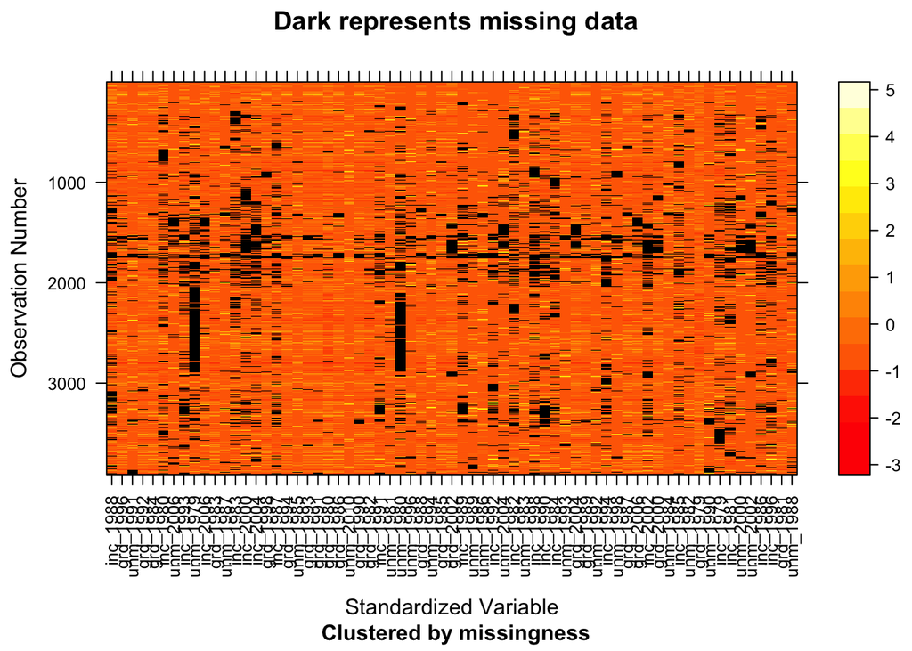

```r
# Display missingness pattern
image(mdf)
```

The package mice implements a simple version of multiple imputation. We can create 4 different imputations by calling:

```r
imp = mice(data, m = 4)
```

We can specify the method of imputation for numerical and categorical variables using the parameter `method`. There are many options, for example, sampling from the non-missing values for each variable:

```r
imp = mice(data, m = 4, method = "sample")
```

Or predicting using linear regression without error (m = 1 yields single imputation):

```r
imp = mice(data, m = 1, method = "norm.predict")
```

The alternative package mi detects a class for each variable and uses sophisticated default regression methods for each class.

```r
show(mdf)
```

```
## Object of class missing_data.frame with 3910 observations on 67 variables
##
## There are 3093 missing data patterns
##
## Append '@patterns' to this missing_data.frame to access the corresponding pattern for every observation or perhaps use table()
##
##                         type missing method  model
## income_1988       continuous     853    ppd linear
## grade_1996        continuous     161    ppd linear
## unemployment_1991 continuous     217    ppd linear
## grade_1992        continuous     121    ppd linear
## grade_1984        continuous      86    ppd linear
## income_1980       continuous     801    ppd linear
## unemployment_2006 continuous     379    ppd linear
## income_1993       continuous     877    ppd linear
## unemployment_1979 continuous    1505    ppd linear
## income_2006       continuous     431    ppd linear
## grade_1983        continuous      78    ppd linear
## unemployment_1987 continuous     218    ppd linear
## income_1983       continuous     816    ppd linear
## income_2000       continuous     920    ppd linear
## income_2004       continuous     777    ppd linear
## grade_1998        continuous     218    ppd linear
## income_1987       continuous     819    ppd linear
## grade_1994        continuous     114    ppd linear
## unemployment_1985 continuous     139    ppd linear
## grade_1993        continuous     103    ppd linear
## grade_1991        continuous     129    ppd linear
## grade_1980        continuous     106    ppd linear
## grade_1986        continuous     143    ppd linear
## unemployment_2010 continuous       0   <NA>   <NA>
## grade_1990        continuous     168    ppd linear
## grade_1982        continuous     105    ppd linear
## income_1991       continuous     658    ppd linear
## unemployment_1981 continuous     113    ppd linear
## unemployment_1980 continuous    1491    ppd linear
## unemployment_1996 continuous     241    ppd linear
## grade_1988        continuous     184    ppd linear
## unemployment_1994 continuous     189    ppd linear
## grade_1985        continuous     115    ppd linear
```

[output cut: 88 more lines]

```
## income_2002       gaussian identity    standardize
## grade_2000        gaussian identity    standardize
## unemployment_1984 gaussian identity    standardize
## income_1985       gaussian identity    standardize
## unemployment_1982 gaussian identity    standardize
## grade_1979        gaussian identity    standardize
## unemployment_1990 gaussian identity    standardize
## income_1979       gaussian identity    standardize
## income_1981       gaussian identity    standardize
## unemployment_2000 gaussian identity    standardize
## unemployment_2002 gaussian identity    standardize
## income_1986       gaussian identity    standardize
## income_1996       gaussian identity    standardize
## grade_1981        gaussian identity    standardize
## unemployment_1988 gaussian identity    standardize
```

The equivalent of the function `mice` above is called `mi`. A warning from the mi vignette: “The imputation step can be quite time consuming, particularly if there are many missing_variables and if many of them are categorical.”

```r
imp = mi(mdf)
```

### Low-rank matrix completion

The package softImpute implements an algorithm that completes a data matrix while restricting the rank of the completion. The function `softImpute` allows you to specify a maximum rank:

```r
softImp = softImpute(as.matrix(data), rank.max = 60)
data.completed = softImp$u %*% diag(softImp$d) %*% t(softImp$v)
```

We can examine the MSE of the completion on the non-missing entries:

```r
mean((data.completed[!is.na(data)] - data[!is.na(data)])^2)
```

```
## [1] 0.07941561
```

This averaged deviation will increase as we reduce the rank. For example:

```r
softImp = softImpute(as.matrix(data), rank.max = 30)
data.completed = softImp$u %*% diag(softImp$d) %*% t(softImp$v)
mean((data.completed[!is.na(data)] - data[!is.na(data)])^2)
```

```
## [1] 13.40608
```

In practice, we could use `rank.max` as a tuning parameter and select it through cross-validation. The function softImpute also takes a parameter `lambda`, which determines a penalty on the nuclear norm of the completed matrix. You can also use this as a tuning parameter.